# 70-467 Machine Learning for Business Analytics

## What did each method change, and what did it buy?

1 · Bagging 2 · Random forest 3 · Boosting

|  | Bagging average | Random forest average | Boosting → → → |
| --- | --- | --- | --- |
| Hours each tree sees | Bootstrap sample | Bootstrap sample | All training hours |
| Tree size | Deep, unpruned | Deep, unpruned | Small, depth 3 |
| Predictors a split may try | All 10 | 3 by lot | All 10 |
| How trees combine | Average P(High) | Average P(High) | Add λ = 0.05 of each, in sequence |
| Setting on training hours | B = 500; more never hurts | mtry = 3 on OOB | B = 561 by 5-fold CV; more can hurt |

Write down your guess: which of the three has the lowest test RMSE, and by how much?

## Which model predicts best on the same test hours?

1 · Bagging 2 · Random forest 3 · Boosting

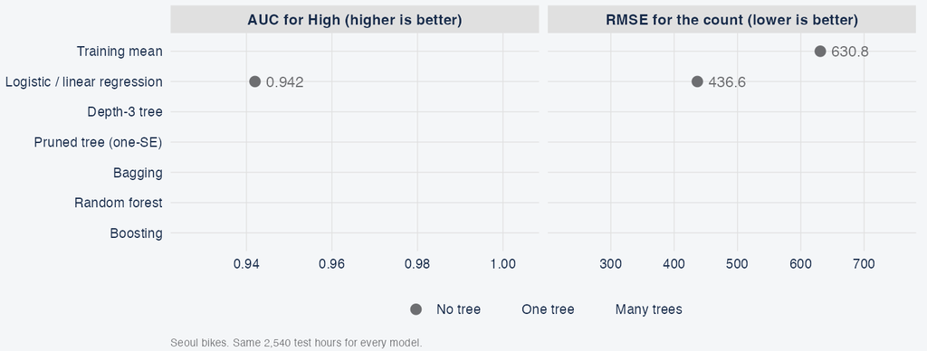

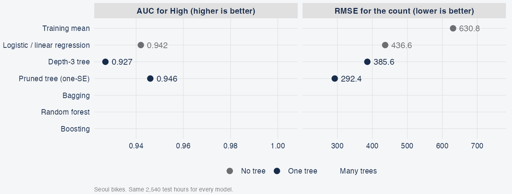

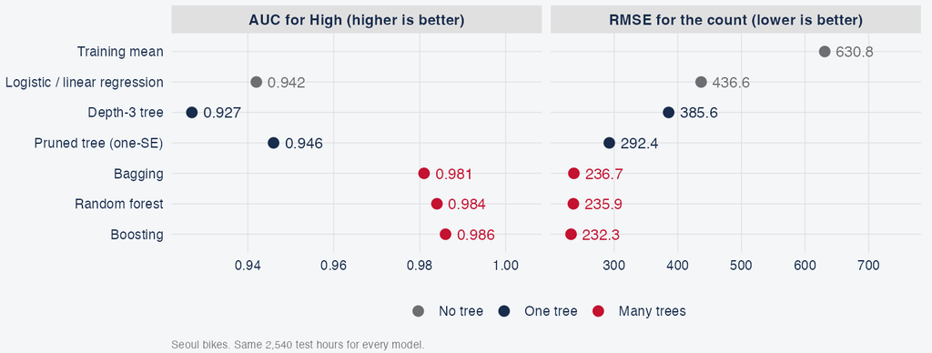

Three lines are still empty. Where will bagging, the forest and boosting land?

- **The ensembles beat one tree and are close to each other:** AUC 0.981, 0.984 and 0.986 against 0.946 for the pruned tree; RMSE 236.7, 235.9 and 232.3 against 292.4.
- **In rentals:** boosting misses a typical test hour by 232.3, about 60 fewer than the pruned tree's 292.4.
- **Every setting was chosen on the training hours. The test hours only score.**

## Do the scores hold for days the model has not seen?

1 · Bagging 2 · Random forest 3 · Boosting

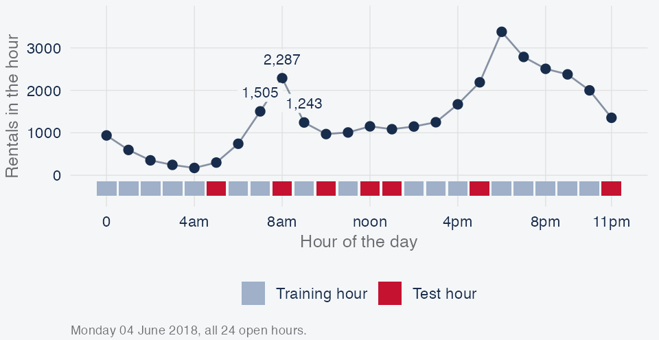

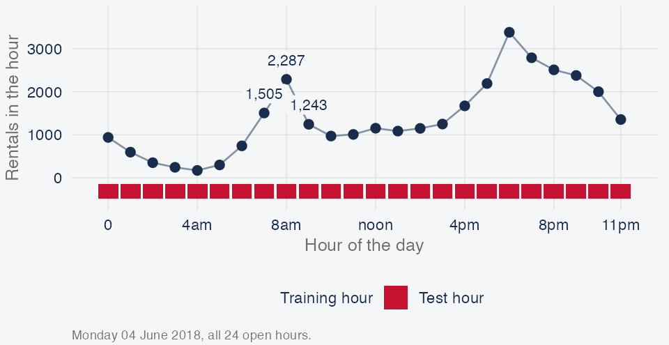

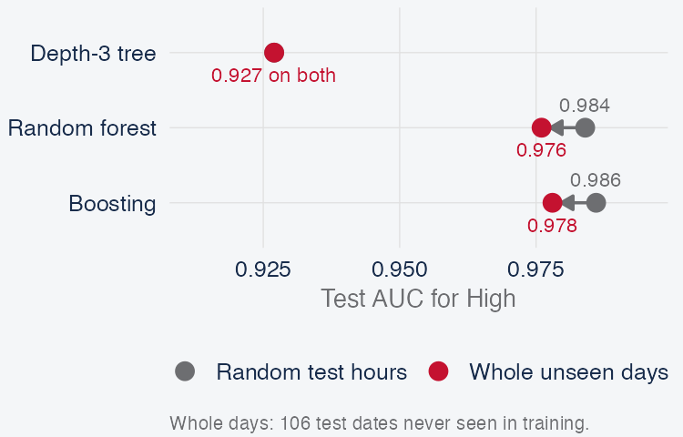

8am is a test hour; 7am and 9am are training hours. How hard is it to predict 8am?

- **Neighbouring hours are alike:** rentals in consecutive open hours correlate 0.902.
- **Every test date is also a training date,** and 89.6% of test hours have a neighbouring hour from the same day in training.
- **Whole-day split:** no date in both parts.
- On whole unseen days the depth-3 tree’s AUC is 0.927; the forest and boosting lose a little and still lead.

```r
set.seed(467)                                                       # same seed
dsplit <- group_initial_split(bikes, group = date, prop = 0.70)     # whole days go to training or to test
dtr <- training(dsplit); dte <- testing(dsplit)                     # no date in both parts
c(train = nrow(dtr), test = nrow(dte),                              # hours in each part
  test_days = length(unique(dte$date)),                             # dates held out
  shared = length(intersect(dtr$date, dte$date)))                   # dates in both parts
```

```
    train      test test_days    shared
     5921      2544       106         0
```

## What will we answer in the lab?

Lab 6

How much better are the combined models on hours they have not seen, and is that worth giving up the rules a planner can read?

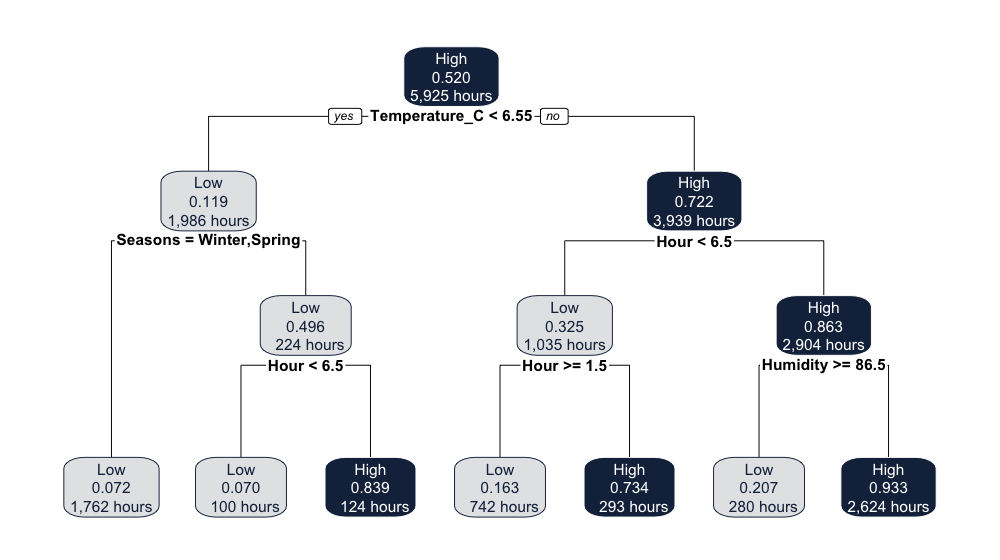

One tree: rules a planner can read. Test AUC 0.927.

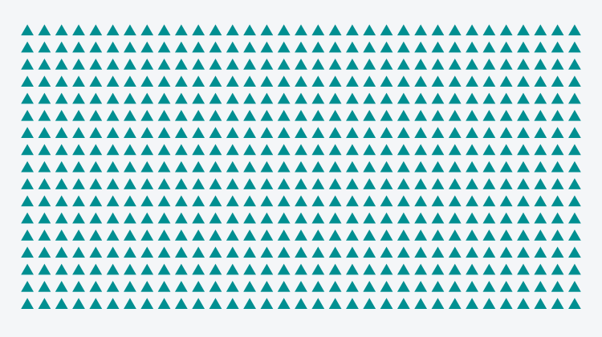

Boosting: 561 trees, one triangle each. Test AUC 0.986.

In the lab you compare five models for High on the same validation hours, by AUC and by accuracy at 0.50. Each of you chooses one model and writes down why. Only that model is estimated again and reported on the test hours, once.

## What should we check before trusting a tree?

1. **Is a tree appropriate?** Yes: rentals have two peaks over the day, which a straight line misses. Slide 8

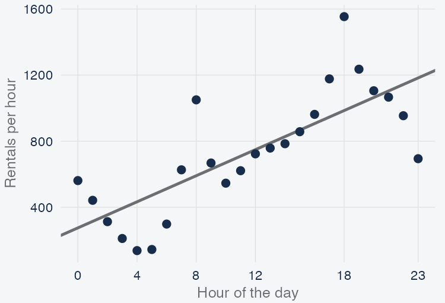

2. **Is this tree overfit?** The full tree is: 95 splits, and a higher test error than the pruned tree. Slide 19

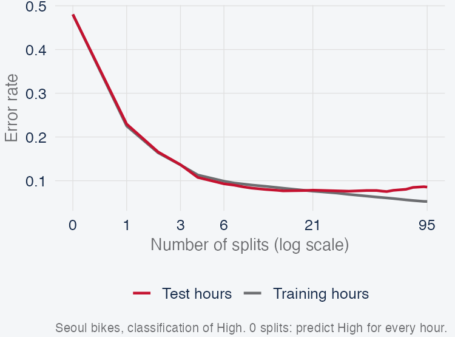

3. **Was it pruned by cross-validation, and were ensembles tried?** Pruned with 10-fold CV and the one-SE rule; bagging, a random forest and boosting were tried. Slides 22 and 43

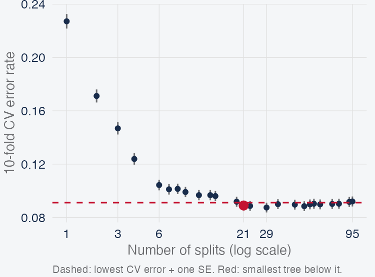

4. **Is accuracy reported on data used neither to grow the tree nor to choose it?** Yes: the test hours only score, and whole unseen days are checked too. Slides 43 and 44

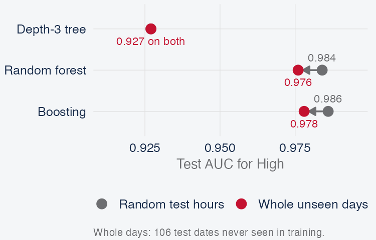

## How many bikes will Seoul riders rent in the next hour?

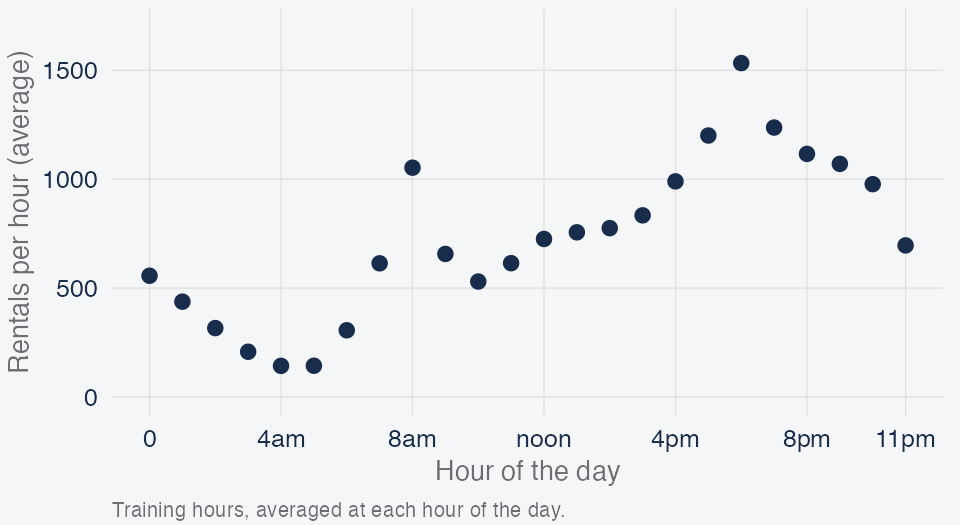

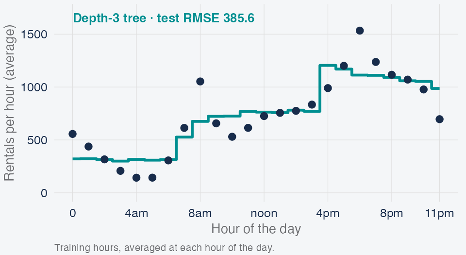

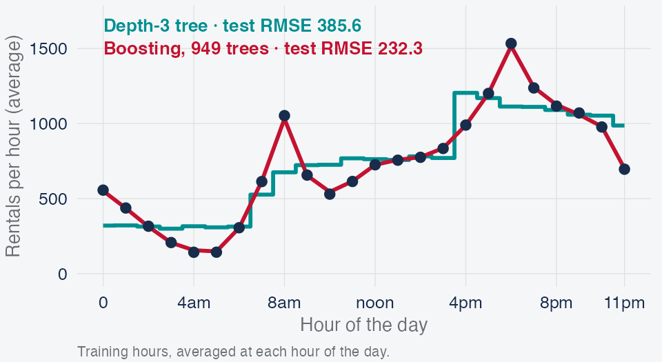

1. **One tree says why.** Warm hours from 7am are High unless humidity is 87% or more; cold winter and spring hours are Low (the depth-3 tree, slide 18).
2. **Many trees predict best** on the horse-race and whole-day slides; boosting leads narrowly.
3. **The trade-off:** one tree can be read; an ensemble predicts better.

## How does training RMSE fall as boosting adds trees?

Backup: count model path from slide 39

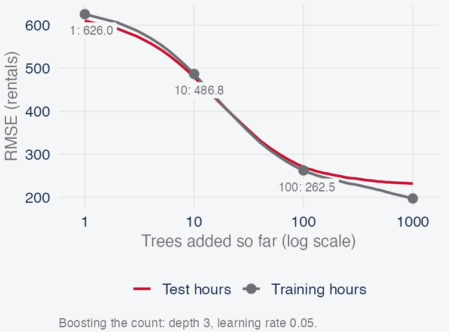

- **Same path as the RMSE strip on slide 39**, now as a curve. Training: 626.0 → 197.3. Test: 610.7 → 232.1.
- **Depth 3; λ = 0.05.** For High or Low, CV later stops short of 1,000 trees.

## How does the hour move the boosted prediction?

Backup: the textbook’s lab, section 8.3.4

```r
pd_hour <- partial(boost, pred.var = "Hour", train = x_tr,           # set every training hour's Hour to 0, 1, ..., 23
                   pred.fun = function(object, newdata) mean(predict(object, newdata)),  # average P(High) at each value
                   grid.resolution = 24)                              # one point per hour of the day
round(pd_hour$yhat[pd_hour$Hour %in% c(4, 8, 18)], 3)               # 4am, 8am and 6pm
```

```
[1] 0.029 0.770 0.800
```

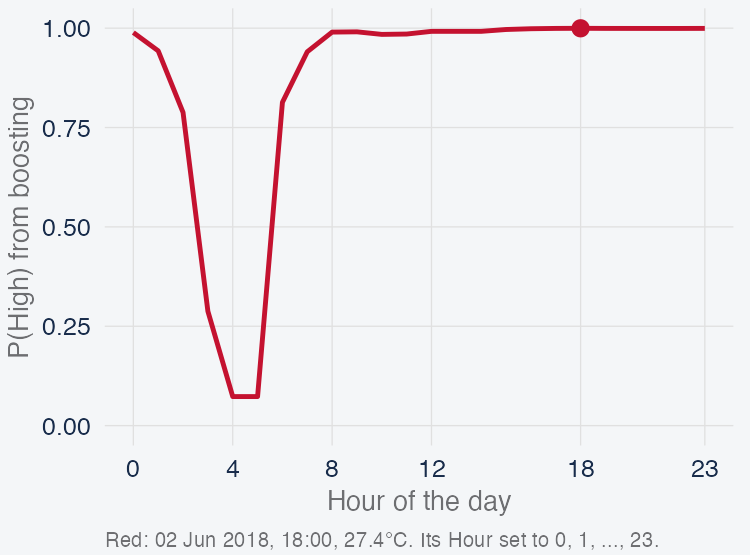

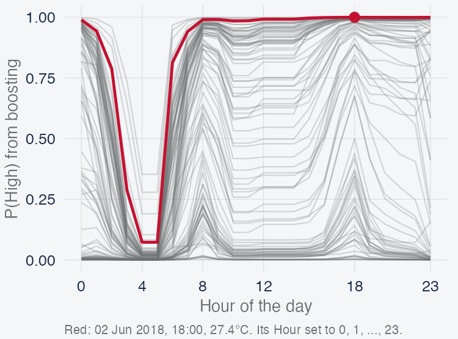

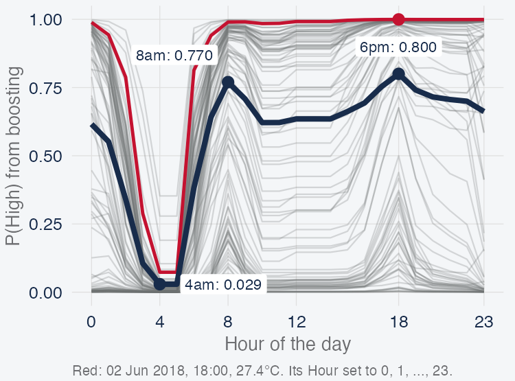

- **One training hour:** 2 June 2018 at 6pm, 27.4°C. Set its Hour to 0, 1, …, 23 and keep everything else; the red line is its P(High).
- **100 training hours, one line each.** Some stay low at every hour; others are high except at night.
- **Partial dependence:** set every training hour’s Hour to one value, keep the other predictors as observed, and average the predicted P(High).
- **4am: 0.029. 8am: 0.770. 6pm: 0.800.**
- **The two peaks of slide 8 survive inside 561 trees.**